# Analysys of gym customer profiles and what to do to keep them, customer retention strategy.

by Yotam dadon, Marketing growth data analyst.

- LinkedIn- [Click here for linkedIn](https://www.linkedin.com/in/yotamdadon/)
- Facebook- [Click here for FaceBook](https://www.facebook.com/yotamdadon/)
- Email- ytmddn@gmail.com

## project Goals:

- Learn to predict the probability of churn (for the upcoming month) for each customer
- Draw up typical user portraits: select the most outstanding groups and describe their main features
- Analyze the factors that impact churn most.
- Draw basic conclusions and develop recommendations on how to improve customer service:
  - Identify target groups.
  - Suggest measures to cut churn.
  - Describe any other patterns you see with respect to interaction with customers.

#### Step 1. Download the data

Conclusion step_1

#### Step 2. Exploratory data analysis (EDA)

2.1. Does it contain any missing features? Study the mean values and standard deviation.

2.2. Look at the mean feature values in two groups: for those who left (churn) and for those who stayed.

2.3. Plot bar histograms and feature distributions for those who left (churn) and those who stayed.

2.4. Build a correlation matrix.

##### Conclusion Step 2

#### Step 3. Build a model to predict user churn

3.1. Divide the data into train and validation sets using the train_test_split() function.

3.2. Train the model on the train set with two methods: logistic regression random forest

3.3. Evaluate accuracy, precision, and recall for both models using the validation data. Use them to compare the models. Which model gave better results?

#### Conclusion step_3

#### Step 4. Create user clusters

4.1.Standardize the data.

4.2. Use the linkage() function to build a matrix of distances based on the standardized feature matrix and plot a dendrogram. Use the resulting graph to estimate the number of clusters you can single out.

4.3. Train the clustering model with the K-means algorithm and predict customer clusters.

4.4. Look at the mean feature values for clusters.

4.5. Plot distributions of features for the clusters.

4.6. Calculate the churn rate for each cluster. Do they differ in terms of churn rate?

#### Conclusion step_4

#### Step 5. Come up with conclusions and basic recommendations on working with customers

5.1. Draw conclusions and formulate recommendations regarding the strategy for customer interaction and retention.

#### Conclusion step_5

#### General Conclusions

Reviewer's comment v. 1: It’s great that you added a table of contents with links, but please add a goal of the project.

```python
import pandas as pd
import numpy as np
import datetime as dt
import seaborn as sns
from matplotlib import pyplot as plt
import scipy.stats as stats
import plotly.express as px

import matplotlib
import matplotlib.pyplot as plt
import matplotlib.gridspec as gridspec
from matplotlib.gridspec import GridSpec

import warnings
warnings.filterwarnings('ignore')

from sklearn.preprocessing import StandardScaler
from sklearn.model_selection import train_test_split
from sklearn.linear_model import LogisticRegression
from sklearn.ensemble import RandomForestRegressor
from sklearn.ensemble import RandomForestClassifier, GradientBoostingClassifier
from sklearn.metrics import accuracy_score, precision_score, recall_score, f1_score
from sklearn.metrics import balanced_accuracy_score
from scipy.cluster.hierarchy import dendrogram, linkage
from sklearn.cluster import KMeans
```

## Step1. Download the data

```python
#Import the tables
GYM_CHURN_PATH_LOCAL = '/Users/yotamdadon/Documents/Data_Analyst/Forcasting- ML/gym_churn_us.csv'

GYM_CHURN_PATH_ONLINE = '/datasets/gym_churn_us.csv'


try:
    gym_churn= pd.read_csv(GYM_CHURN_PATH_LOCAL)

except:
    gym_churn = pd.read_csv(GYM_CHURN_PATH_ONLINE)


gym_churn.columns = gym_churn.columns.str.lower()
```

```python
gym_churn.shape
```

```
(4000, 14)
```

```python
gym_churn.info()
```

```
<class 'pandas.core.frame.DataFrame'>
RangeIndex: 4000 entries, 0 to 3999
Data columns (total 14 columns):
 #   Column                             Non-Null Count  Dtype
---  ------                             --------------  -----
 0   gender                             4000 non-null   int64
 1   near_location                      4000 non-null   int64
 2   partner                            4000 non-null   int64
 3   promo_friends                      4000 non-null   int64
 4   phone                              4000 non-null   int64
 5   contract_period                    4000 non-null   int64
 6   group_visits                       4000 non-null   int64
 7   age                                4000 non-null   int64
 8   avg_additional_charges_total       4000 non-null   float64
 9   month_to_end_contract              4000 non-null   float64
 10  lifetime                           4000 non-null   int64
 11  avg_class_frequency_total          4000 non-null   float64
 12  avg_class_frequency_current_month  4000 non-null   float64
 13  churn                              4000 non-null   int64
dtypes: float64(4), int64(10)
memory usage: 437.6 KB
```

```python
gym_churn
```

|  | gender | near_location | partner | promo_friends | phone | contract_period | group_visits | age | avg_additional_charges_total | month_to_end_contract | lifetime | avg_class_frequency_total | avg_class_frequency_current_month | churn |
| --- | --- | --- | --- | --- | --- | --- | --- | --- | --- | --- | --- | --- | --- | --- |
| 0 | 1 | 1 | 1 | 1 | 0 | 6 | 1 | 29 | 14.227470 | 5.0 | 3 | 0.020398 | 0.000000 | 0 |
| 1 | 0 | 1 | 0 | 0 | 1 | 12 | 1 | 31 | 113.202938 | 12.0 | 7 | 1.922936 | 1.910244 | 0 |
| 2 | 0 | 1 | 1 | 0 | 1 | 1 | 0 | 28 | 129.448479 | 1.0 | 2 | 1.859098 | 1.736502 | 0 |
| 3 | 0 | 1 | 1 | 1 | 1 | 12 | 1 | 33 | 62.669863 | 12.0 | 2 | 3.205633 | 3.357215 | 0 |
| 4 | 1 | 1 | 1 | 1 | 1 | 1 | 0 | 26 | 198.362265 | 1.0 | 3 | 1.113884 | 1.120078 | 0 |
| ... | ... | ... | ... | ... | ... | ... | ... | ... | ... | ... | ... | ... | ... | ... |
| 3995 | 1 | 1 | 1 | 0 | 1 | 12 | 0 | 33 | 2.406023 | 12.0 | 8 | 2.284497 | 2.349070 | 0 |
| 3996 | 0 | 1 | 0 | 0 | 1 | 1 | 1 | 29 | 68.883764 | 1.0 | 1 | 1.277168 | 0.292859 | 1 |
| 3997 | 1 | 1 | 1 | 1 | 1 | 12 | 0 | 28 | 78.250542 | 11.0 | 2 | 2.786146 | 2.831439 | 0 |
| 3998 | 0 | 1 | 1 | 1 | 1 | 6 | 0 | 32 | 61.912657 | 5.0 | 3 | 1.630108 | 1.596237 | 0 |
| 3999 | 1 | 0 | 1 | 0 | 0 | 12 | 1 | 30 | 178.861814 | 12.0 | 1 | 1.101832 | 1.035270 | 0 |

4000 rows × 14 columns

## Conclusions step 1

## Conclusion download the data: • Binary values - We have columns and 4000 indencies with no missing values, gender, near_location, partner, promo_friends, phone, group_visits. • Continuous values- contract_period, age, avg_additional_charges_total, month_to_end_contract, lifetime, avg_class_frequency_total, avg_class_frequency_current_month.

## Step 2. Carry out exploratory data analysis (EDA)

### Look at the dataset: does it contain any missing features? Study the mean values and standard deviation (use the describe() method).

```python
gym_churn.describe()
```

|  | gender | near_location | partner | promo_friends | phone | contract_period | group_visits | age | avg_additional_charges_total | month_to_end_contract | lifetime | avg_class_frequency_total | avg_class_frequency_current_month | churn |
| --- | --- | --- | --- | --- | --- | --- | --- | --- | --- | --- | --- | --- | --- | --- |
| count | 4000.000000 | 4000.000000 | 4000.000000 | 4000.000000 | 4000.000000 | 4000.000000 | 4000.000000 | 4000.000000 | 4000.000000 | 4000.000000 | 4000.000000 | 4000.000000 | 4000.000000 | 4000.000000 |
| mean | 0.510250 | 0.845250 | 0.486750 | 0.308500 | 0.903500 | 4.681250 | 0.412250 | 29.184250 | 146.943728 | 4.322750 | 3.724750 | 1.879020 | 1.767052 | 0.265250 |
| std | 0.499957 | 0.361711 | 0.499887 | 0.461932 | 0.295313 | 4.549706 | 0.492301 | 3.258367 | 96.355602 | 4.191297 | 3.749267 | 0.972245 | 1.052906 | 0.441521 |
| min | 0.000000 | 0.000000 | 0.000000 | 0.000000 | 0.000000 | 1.000000 | 0.000000 | 18.000000 | 0.148205 | 1.000000 | 0.000000 | 0.000000 | 0.000000 | 0.000000 |
| 25% | 0.000000 | 1.000000 | 0.000000 | 0.000000 | 1.000000 | 1.000000 | 0.000000 | 27.000000 | 68.868830 | 1.000000 | 1.000000 | 1.180875 | 0.963003 | 0.000000 |
| 50% | 1.000000 | 1.000000 | 0.000000 | 0.000000 | 1.000000 | 1.000000 | 0.000000 | 29.000000 | 136.220159 | 1.000000 | 3.000000 | 1.832768 | 1.719574 | 0.000000 |
| 75% | 1.000000 | 1.000000 | 1.000000 | 1.000000 | 1.000000 | 6.000000 | 1.000000 | 31.000000 | 210.949625 | 6.000000 | 5.000000 | 2.536078 | 2.510336 | 1.000000 |
| max | 1.000000 | 1.000000 | 1.000000 | 1.000000 | 1.000000 | 12.000000 | 1.000000 | 41.000000 | 552.590740 | 12.000000 | 31.000000 | 6.023668 | 6.146783 | 1.000000 |

### Look at the mean feature values in two groups: for those who left (churn) and for those who stayed (use the groupby() method).

```python
churn = round(gym_churn.groupby('churn').mean().reset_index(),3)
display(churn)
```

|  | churn | gender | near_location | partner | promo_friends | phone | contract_period | group_visits | age | avg_additional_charges_total | month_to_end_contract | lifetime | avg_class_frequency_total | avg_class_frequency_current_month |
| --- | --- | --- | --- | --- | --- | --- | --- | --- | --- | --- | --- | --- | --- | --- |
| 0 | 0 | 0.510 | 0.873 | 0.534 | 0.354 | 0.904 | 5.747 | 0.464 | 29.977 | 158.446 | 5.283 | 4.712 | 2.025 | 2.028 |
| 1 | 1 | 0.511 | 0.768 | 0.355 | 0.184 | 0.903 | 1.729 | 0.269 | 26.990 | 115.083 | 1.663 | 0.991 | 1.475 | 1.045 |

### Main diferences between stay and churn: - gender: is balnaced between males and females - for other binary features we will have a better understanding once we visualize it - contract period - those who leaves have **shorter contract periods** - age - those who leave tend to a be the age of **26-27 or younger** - avg_additional_charges_total - the mean total additional charges of stayers is 158$,for leavers is 115$ - lifetime - leavers tend to leave up to 1 month after thier subscription - How often to they visit the gym (both absolute and relative) - those who stay, come to the gym 2 times a week, in apose to the leavers: 1.5 times.

## Plot bar histograms and feature distributions for those who left (churn) and those who stayed.

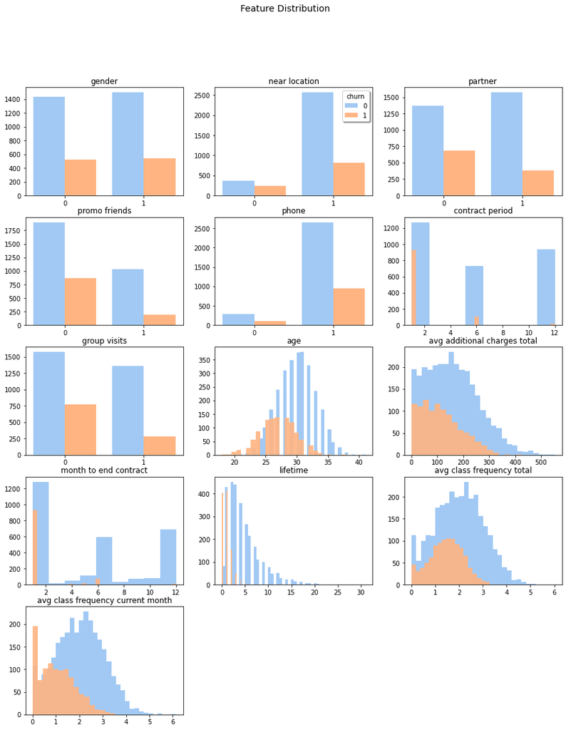

```python
#lets set the visual palet and figure and grid size
sns.set_palette("pastel", 5)
plt.figure(figsize=(15,18))
the_grid = GridSpec(5, 3)
#loop thrue the dataframs features and plot them, use countplot if they are binary and distplot if they are not binary
for i,column in enumerate(gym_churn.drop('churn', axis=1).columns):
    plt.subplot(the_grid[i//3, i%3], title=column.replace('_',' '))
    if gym_churn[column].unique().sum() == 1:
        sns.countplot(x=column, hue='churn', data=gym_churn,saturation = 1)
        plt.xlabel('')
        plt.ylabel('')
        plt.gca().get_legend().remove()

        if column == 'near_location':
            legend = gym_churn['churn'].unique()
            plt.legend(legend, shadow=True, fancybox=True, title='churn', loc='best')
    if gym_churn[column].unique().sum() > 1:
        sns.distplot(gym_churn[gym_churn['churn'] == 0][column], hist = True, kde = False, hist_kws = {'linewidth': 1,'alpha': 1})
        sns.distplot(gym_churn[gym_churn['churn'] == 1][column], hist = True, kde = False, hist_kws = {'linewidth': 1,'alpha': 0.9})
        plt.xlabel('')
        plt.ylabel('')



plt.suptitle('Feature Distribution', fontsize = 14)
#plt.tight_layout()
plt.show()
```

## Build a correlation matrix and display it.

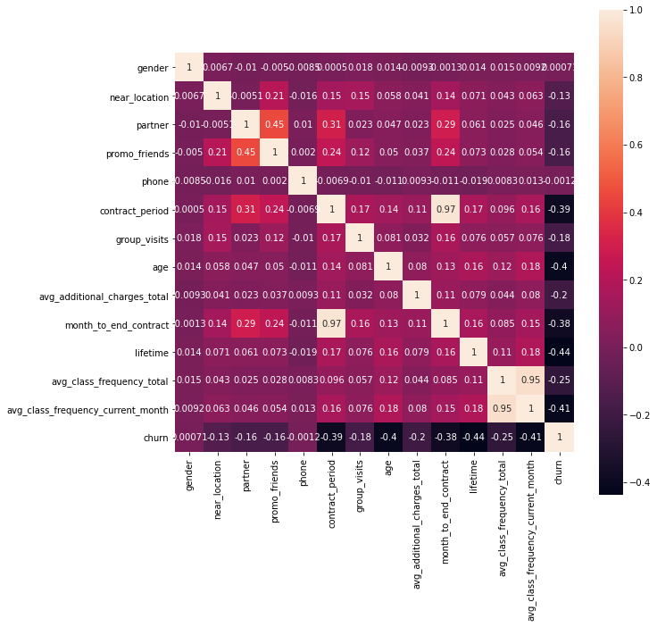

```python
corrMatrix = gym_churn.corr()
fig, ax = plt.subplots(figsize=(10,10))
sns.heatmap(corrMatrix, annot=True,square = True)
plt.show()
```

Reviewer's comment v. 1: An excellent heatmap, but please add title to the graph. I also recommend to remove special character "_" from the labels.

There is a Significantly high correlation between month_to_end_contract to contract_period. since this is abviously corelated it will benifit us to remove it from our matrix in order for us to see corelations better.

```python
corrMatrix = corrMatrix.drop('month_to_end_contract',axis = 1)
corrMatrix = corrMatrix.drop('month_to_end_contract',axis = 0)
```

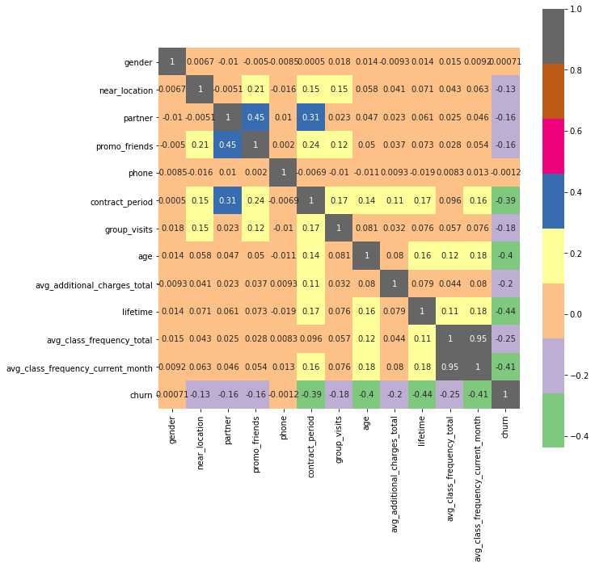

```python
fig, ax = plt.subplots(figsize=(10,10))
sns.heatmap(corrMatrix, annot=True, square = True,cmap='Accent')
plt.show()
```

Reviewer's comment v. 1: Yes, we have correlation between variables. Please note that correlation function shows only linear dependecy between variables. Maybe this link will be interesting for you: https://machinelearningmastery.com/how-to-use-correlation-to-understand-the-relationship-between-variables/.

## Step 3. Build a model to predict user churn

Build a binary classification model for customers where the target feature is the user's leaving next month.

### Divide the data into train and validation sets using the train_test_split() function.

```python
X = gym_churn.drop('churn', axis = 1)
y = gym_churn['churn']

# divide the data into train and test sets
X_train, X_test, y_train, y_test = train_test_split(X, y, test_size=0.2, random_state=0)

# train StandardScaler on the train set
scaler = StandardScaler()
scaler.fit(X_train)
```

```
StandardScaler()
```

### Train the model on the train set with two methods:

```
• logistic regression
• random forest
```

### Evaluate accuracy, precision, and recall for both models using the validation data. Use them to compare the models. Which model gave better results?

```python
# define the function that will output our metrics
def print_all_metrics(y_true, y_pred, y_proba, title = 'Classification metrics'):
    print(title)
    print('\tAccuracy: {:.2f}'.format(accuracy_score(y_true, y_pred)))
    print('\tBalanced Accuracy: {:.2f}'.format((balanced_accuracy_score(y_true,y_pred))))
    print('\tPrecision: {:.2f}'.format(precision_score(y_true, y_pred)))
    print('\tRecall: {:.2f}'.format(recall_score(y_true, y_pred)))
    print('\tF1: {:.2f}'.format(f1_score(y_true, y_pred)))
```

```python
# define the Logistic regression model
lr_model = LogisticRegression(random_state=0)

# train the model
lr_model.fit(X_train, y_train)

# use the trained model to make forecasts
predictions = lr_model.predict(X_test)
probabilities = lr_model.predict_proba(X_test)[:,1]



# define the algorithm for the logistic regression model
lr_model = LogisticRegression(random_state=0)
# train the model
lr_model.fit(X_train, y_train)
# use the trained model to make predictions
lr_predictions = lr_model.predict(X_test)
lr_probabilities = lr_model.predict_proba(X_test)[:,1]
# print all metrics
print_all_metrics(y_test, lr_predictions, lr_probabilities , title='Metrics for logistic regression:')
```

```
Metrics for logistic regression:
	Accuracy: 0.91
	Balanced Accuracy: 0.87
	Precision: 0.82
	Recall: 0.80
	F1: 0.81
```

```python
# defining the new model's algorithm based on the random forest algorithm
rf_model = RandomForestRegressor(n_estimators = 100,random_state = 0)

# train the model
rf_model.fit(X_train, y_train)

# use the trained model to make forecasts
y_pred = rf_model.predict(X_test)



# define the algorithm for the new random forest model
rf_model = RandomForestClassifier(n_estimators = 100, random_state = 0)
# train the random forest model
rf_model.fit(X_train, y_train)
# use the trained model to make predictions
rf_predictions = rf_model.predict(X_test) # write your code here
rf_probabilities = rf_model.predict_proba(X_test)[:,1]# write your code here
# print all metrics
print_all_metrics(y_test, rf_predictions, rf_probabilities, title = 'Metrics for random forest:')
```

```
Metrics for random forest:
	Accuracy: 0.92
	Balanced Accuracy: 0.88
	Precision: 0.84
	Recall: 0.82
	F1: 0.83
```

## Step 4. Create user clusters

Set aside the column with data on churn and identify object (user) clusters:

### Standardize the data.

```python
scaler = StandardScaler() # creating a scaler class object (normalizer)
x_sc = scaler.fit_transform(gym_churn.drop(columns = ['churn']))
print(x_sc[:10])
```

```
[[ 0.97970588  0.42788074  1.02686062  1.49716101 -3.05985201  0.28989014
   1.19403206 -0.0565538  -1.37753121  0.16160501 -0.19332863 -1.91191971
  -1.67847198]
 [-1.0207145   0.42788074 -0.973842   -0.66793083  0.32681319  1.60882159
   1.19403206  0.55732732 -0.35021325  1.83194105  0.87368001  0.04517569
   0.1360137 ]
 [-1.0207145   0.42788074  1.02686062 -0.66793083  0.32681319 -0.8092194
  -0.83749845 -0.36349436 -0.1815923  -0.79287273 -0.46008079 -0.02049263
  -0.02901851]
 [-1.0207145   0.42788074  1.02686062  1.49716101  0.32681319  1.60882159
   1.19403206  1.17120844 -0.87472237  1.83194105 -0.46008079  1.36465509
   1.51045005]
 [ 0.97970588  0.42788074  1.02686062  1.49716101  0.32681319 -0.8092194
  -0.83749845 -0.97737548  0.5336998  -0.79287273 -0.19332863 -0.78707638
  -0.61454183]
 [ 0.97970588  0.42788074 -0.973842   -0.66793083  0.32681319 -0.8092194
   1.19403206  1.478149    3.15330097 -0.79287273 -0.19332863  0.76580519
   0.82634551]
 [ 0.97970588  0.42788074  1.02686062  1.49716101 -3.05985201  0.28989014
   1.19403206  0.86426788 -0.54676556  0.40022445 -0.46008079 -0.76130102
  -0.46525669]
 [-1.0207145   0.42788074 -0.973842   -0.66793083  0.32681319 -0.8092194
  -0.83749845  0.25038676  0.73531552 -0.79287273 -0.99358511 -0.68460218
  -0.68168915]
 [ 0.97970588  0.42788074  1.02686062  1.49716101  0.32681319 -0.8092194
   1.19403206 -1.89819716 -1.05387243 -0.79287273 -0.72683295 -0.79494109
  -0.67224189]
 [-1.0207145   0.42788074 -0.973842   -0.66793083  0.32681319 -0.8092194
  -0.83749845  0.55732732 -0.84731033 -0.79287273  1.94068865 -0.07012259
   0.17507634]]
```

### Use the linkage() function to build a matrix of distances based on the standardized feature matrix and plot a dendrogram.

Note: rendering the dendrogram may take time! Use the resulting graph to estimate the number of clusters you can single out.

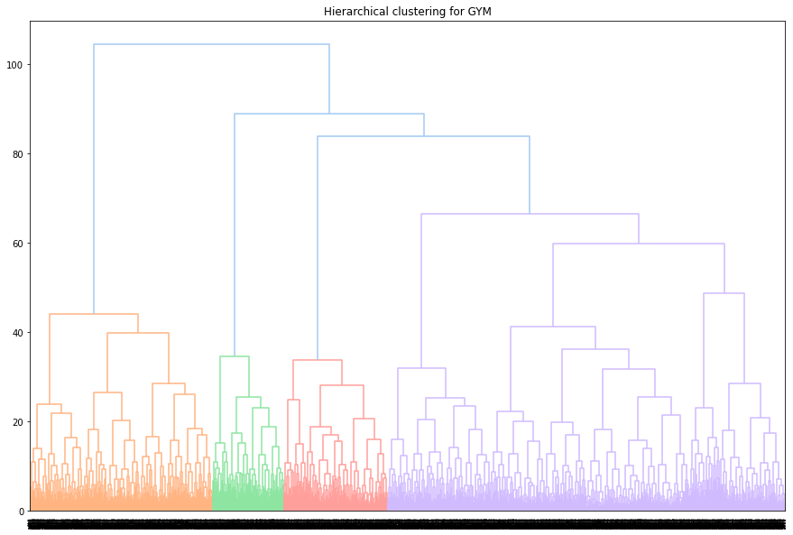

```python
linked = linkage(x_sc, method = 'ward')

plt.figure(figsize=(15, 10))
dendrogram(linked, orientation='top')
plt.title('Hierarchical clustering for GYM')
plt.show()
```

```python
## there are 4 clusters (4 diferent colors)
```

### Train the clustering model with the K-means algorithm and predict customer clusters.

```python
km = KMeans(n_clusters = 4, random_state = 0) # setting the number of clusters as 4
labels = km.fit_predict(x_sc) # applying the algorithm to the data and forming a cluster vector
gym_churn['cluster_km'] = labels
```

### Look at the mean feature values for clusters.

```python
gym_churn
```

|  | gender | near_location | partner | promo_friends | phone | contract_period | group_visits | age | avg_additional_charges_total | month_to_end_contract | lifetime | avg_class_frequency_total | avg_class_frequency_current_month | churn | cluster_km |
| --- | --- | --- | --- | --- | --- | --- | --- | --- | --- | --- | --- | --- | --- | --- | --- |
| 0 | 1 | 1 | 1 | 1 | 0 | 6 | 1 | 29 | 14.227470 | 5.0 | 3 | 0.020398 | 0.000000 | 0 | 0 |
| 1 | 0 | 1 | 0 | 0 | 1 | 12 | 1 | 31 | 113.202938 | 12.0 | 7 | 1.922936 | 1.910244 | 0 | 2 |
| 2 | 0 | 1 | 1 | 0 | 1 | 1 | 0 | 28 | 129.448479 | 1.0 | 2 | 1.859098 | 1.736502 | 0 | 3 |
| 3 | 0 | 1 | 1 | 1 | 1 | 12 | 1 | 33 | 62.669863 | 12.0 | 2 | 3.205633 | 3.357215 | 0 | 2 |
| 4 | 1 | 1 | 1 | 1 | 1 | 1 | 0 | 26 | 198.362265 | 1.0 | 3 | 1.113884 | 1.120078 | 0 | 3 |
| ... | ... | ... | ... | ... | ... | ... | ... | ... | ... | ... | ... | ... | ... | ... | ... |
| 3995 | 1 | 1 | 1 | 0 | 1 | 12 | 0 | 33 | 2.406023 | 12.0 | 8 | 2.284497 | 2.349070 | 0 | 2 |
| 3996 | 0 | 1 | 0 | 0 | 1 | 1 | 1 | 29 | 68.883764 | 1.0 | 1 | 1.277168 | 0.292859 | 1 | 3 |
| 3997 | 1 | 1 | 1 | 1 | 1 | 12 | 0 | 28 | 78.250542 | 11.0 | 2 | 2.786146 | 2.831439 | 0 | 2 |
| 3998 | 0 | 1 | 1 | 1 | 1 | 6 | 0 | 32 | 61.912657 | 5.0 | 3 | 1.630108 | 1.596237 | 0 | 2 |
| 3999 | 1 | 0 | 1 | 0 | 0 | 12 | 1 | 30 | 178.861814 | 12.0 | 1 | 1.101832 | 1.035270 | 0 | 0 |

4000 rows × 15 columns

```python
display(gym_churn.groupby('cluster_km').mean())
```

| cluster_km | gender | near_location | partner | promo_friends | phone | contract_period | group_visits | age | avg_additional_charges_total | month_to_end_contract | lifetime | avg_class_frequency_total | avg_class_frequency_current_month | churn |
| --- | --- | --- | --- | --- | --- | --- | --- | --- | --- | --- | --- | --- | --- | --- |
| 0 | 0.523316 | 0.862694 | 0.471503 | 0.305699 | 0.0 | 4.777202 | 0.427461 | 29.297927 | 144.208179 | 4.466321 | 3.940415 | 1.854211 | 1.723967 | 0.266839 |
| 1 | 0.541509 | 0.866038 | 0.334906 | 0.200000 | 1.0 | 2.383962 | 0.450943 | 29.998113 | 157.888187 | 2.221698 | 4.710377 | 2.712339 | 2.698750 | 0.092453 |
| 2 | 0.503238 | 0.940796 | 0.777983 | 0.573543 | 1.0 | 10.690102 | 0.532840 | 29.899167 | 161.051935 | 9.760407 | 4.721554 | 1.993064 | 1.984827 | 0.029602 |
| 3 | 0.489477 | 0.755601 | 0.386286 | 0.192804 | 1.0 | 1.899525 | 0.291921 | 28.044128 | 129.431049 | 1.806517 | 2.227427 | 1.202154 | 0.948054 | 0.562118 |